# Lab 8: Factorial ANOVA

PSYC 6802

October 29, 2025

## Packages for Today

```r
library(tidyverse)
library(rio)
library(effectsize)
library(labelled)
library(car)
library(ez)
library(sjstats)
library(emmeans)
library(ggeffects)
theme_set(theme_classic())
```

## Data for Today

Rotten Tomatoes Data

- IVs: Genre (Comedy vs. Drama vs. Sci-Fi) and Rating (PG vs. PG-13 vs. R)
- DV: Box office revenue in millions of US dollars

```r
dat <- read_csv("rotten_tomatoes_clean.csv")

dat %>% summary
```

```
      id               title           audienceScore    tomatoMeter
 Length:1910        Length:1910        Min.   :12.00   Min.   : 0.00
 Class :character   Class :character   1st Qu.:47.00   1st Qu.:29.00
 Mode  :character   Mode  :character   Median :63.00   Median :52.00
                                       Mean   :61.92   Mean   :51.74
                                       3rd Qu.:78.00   3rd Qu.:75.00
                                       Max.   :99.00   Max.   :98.00

    rating          ratingContents     releaseDateTheaters
 Length:1910        Length:1910        Min.   :1980-05-21
 Class :character   Class :character   1st Qu.:2002-09-20
 Mode  :character   Mode  :character   Median :2006-09-29
                                       Mean   :2008-01-30
                                       3rd Qu.:2013-11-01
                                       Max.   :2023-02-03

 releaseDateStreaming runtimeMinutes    genre           originalLanguage
 Min.   :1992-06-02   Min.   : 74    Length:1910        Length:1910
 1st Qu.:2004-08-11   1st Qu.: 95    Class :character   Class :character
 Median :2007-11-27   Median :106    Mode  :character   Mode  :character
 Mean   :2009-07-06   Mean   :109
 3rd Qu.:2014-08-26   3rd Qu.:119
 Max.   :2023-03-28   Max.   :223

   director            writer           boxOffice         distributor
 Length:1910        Length:1910        Length:1910        Length:1910
 Class :character   Class :character   Class :character   Class :character
 Mode  :character   Mode  :character   Mode  :character   Mode  :character




   soundMix          boxOfficeMil
 Length:1910        Min.   :  0.0014
 Class :character   1st Qu.:  5.7000
 Mode  :character   Median : 26.0500
                    Mean   : 53.2256
                    3rd Qu.: 65.2250
                    Max.   :858.4000
                    NA's   :2
```

## Data Cleaning

The DV of box office revenue (`boxOfficeMil`) is missing for two movies, so we will remove these from the data set:

```r
dat <- dat %>% filter(!is.na(boxOfficeMil))
```

We also want to omit movies without the PG, PG-13, or R ratings:

```r
dat <- dat %>% filter(rating %in% c("PG", "PG-13", "R"))
```

Check for a balanced design (equal sample sizes for each combination of groups):

```r
dat %>% select(rating, genre) %>% table
```

```
       genre
rating  Comedy Drama Sci-fi
  PG       228    79     19
  PG-13    334   284    133
  R        273   508     46
```

## Box Plots

Let’s first explore the distribution of these data using box plots:

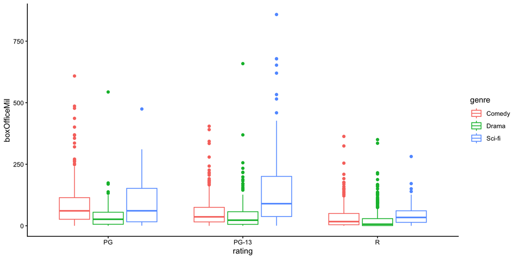

```r
dat %>%
  ggplot(aes(rating, boxOfficeMil, color = genre)) +
  geom_boxplot()
```

## Data Transformation

We see (as we might have anticipated), a large number of positive outliers. This is an instance in which we might prefer to analyze a transformed outcome variable. This time, we’ll use the Box-Cox transformation from Lecture 1.

```r
car::powerTransform(dat$boxOfficeMil)
```

```
Estimated transformation parameter
dat$boxOfficeMil
       0.2164347
```

```r
dat <- dat %>% mutate(boxOffice_transformed = bcPower(boxOfficeMil, lambda = 0.2164347))
```

- With this transformation, we lose the ability to easily interpret the metric of the DV in favor of better meeting our test assumptions.
- Be sure to always apply the exact same transformation to all values (no group-level transformations!)

## Box Plots

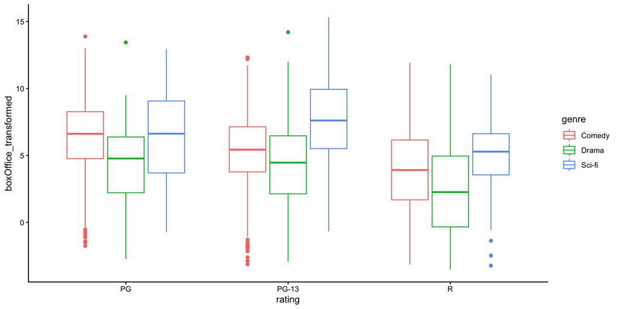

```r
dat %>%
  ggplot(aes(rating, boxOffice_transformed, color = genre)) +
  geom_boxplot()
```

Now, we still have a few outliers, but our data should better meet the normality assumption with the transformed data.

## Interaction Plot

The easiest way to make an interaction plot with `ggplot` is to create a new data set that includes group means.

```r
dat_means <- dat %>%
  group_by(rating, genre) %>%
  summarize(mean_boxOffice_transformed = mean(boxOffice_transformed), .groups = "keep")
```

## Interaction Plot

Then, we can use this to draw an interaction plot.

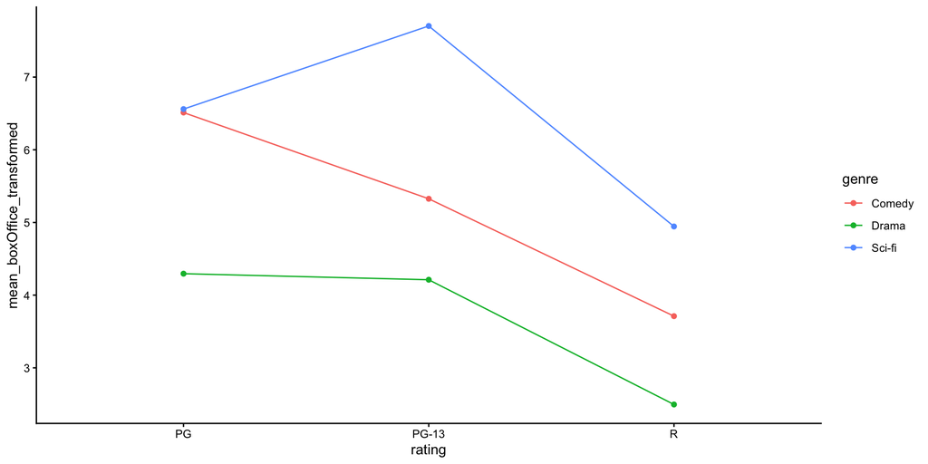

```r
ggplot(dat_means,
       aes(rating, mean_boxOffice_transformed,
           group = genre,
           col = genre)) +
  geom_point() + geom_line()
```

## Formulas in R

Earlier, we saw the `DV ~ IV` notation for formulas.

We can also use `DV ~ IV1 * IV2` to include both main effects and an interaction.

- A longer way to write the same formula is `DV ~ IV1 + IV2 + IV1:IV2`.
- The formula `DV ~ IV1:IV2` includes only the interaction, not the main effects.
- The “*” notation implies all lower-order terms, and the “:” notation implies only the interaction effect.

## Two-Way ANOVA with `aov`

**Warning**: Don’t try this at home if you have unbalanced data!

- If data are unbalanced, the main effects results depend on the order of the variables. Compare the two solutions:
- Rating * Genre
- Genre * Rating

```r
aov_res <- aov(boxOffice_transformed ~ rating * genre, dat)
summary(aov_res)
```

```
               Df Sum Sq Mean Sq F value  Pr(>F)
rating          2   2997  1498.7  153.65 < 2e-16 ***
genre           2   1700   849.8   87.12 < 2e-16 ***
rating:genre    4    140    35.0    3.59 0.00636 **
Residuals    1895  18484     9.8
---
Signif. codes:  0 '***' 0.001 '**' 0.01 '*' 0.05 '.' 0.1 ' ' 1
```

```r
aov_res <- aov(boxOffice_transformed ~ genre * rating, dat)
summary(aov_res)
```

```
               Df Sum Sq Mean Sq F value  Pr(>F)
genre           2   2938  1469.0  150.60 < 2e-16 ***
rating          2   1759   879.5   90.17 < 2e-16 ***
genre:rating    4    140    35.0    3.59 0.00636 **
Residuals    1895  18484     9.8
---
Signif. codes:  0 '***' 0.001 '**' 0.01 '*' 0.05 '.' 0.1 ' ' 1
```

## Two-Way ANOVA with `ezANOVA`

`ezANOVA` in the `ez` package allows us to choose the sums of squares type. Here, we’ll use type 3 SS since we are interested in a potential interaction effect.

```r
ezANOVA(data = dat, dv = boxOffice_transformed,
        between = c(genre, rating), wid = id,
        type = 3)
```

```
$ANOVA
        Effect DFn  DFd         F            p p<.05         ges
2        genre   2 1895 53.005050 3.990588e-23     * 0.052978294
3       rating   2 1895 49.027459 1.738707e-21     * 0.049198302
4 genre:rating   4 1895  3.590136 6.357627e-03     * 0.007521127

$`Levene's Test for Homogeneity of Variance`
  DFn  DFd      SSn      SSd        F            p p<.05
1   8 1895 145.7517 6494.937 5.315667 1.284892e-06     *
```

## Two-Way ANOVA with `ezANOVA`

We rejected the null hypothesis for Levene’s test, so we should use a correction for violations of homogeneity of variance. One option is to use White’s adjustment, which is available with `ezANOVA`.

```r
ezANOVA(data = dat, dv = boxOffice_transformed,
        between = c(genre, rating), wid = id,
        type = 3, white.adjust = TRUE)
```

```
$ANOVA
        Effect DFn  DFd         F            p p<.05
2        genre   2 1895 49.078462 1.656404e-21     *
3       rating   2 1895 49.370951 1.254334e-21     *
4 genre:rating   4 1895  3.370623 9.307024e-03     *

$`Levene's Test for Homogeneity of Variance`
  DFn  DFd      SSn      SSd        F            p p<.05
1   8 1895 145.7517 6494.937 5.315667 1.284892e-06     *
```

## Two-Way ANOVA with `aov`

Another option if homogeneity is violated is to use weighted least squares. We can calculate and specify weights with the `aov` function.

Calculate weights for each combination of groups:

```r
dat <- dat %>%
  group_by(genre, rating) %>%
  mutate(weight = 1 / var(boxOffice_transformed))
```

Run WLS ANOVA:

```r
res_aov <- aov(boxOffice_transformed ~ genre * rating,
               dat, weights = weight)
```

Because we have unbalanced data, we want to print type 2 or 3 sums of squares. Below, we find type 2 sums of squares using the `Anova` function from the `car` package. Note that we do **not** want to use this function to find type 3 sums of squares (use `ezAnova` instead).

```r
Anova(res_aov, type = 2)
```

```
Anova Table (Type II tests)

Response: boxOffice_transformed
              Sum Sq   Df F value    Pr(>F)
genre         171.39    2 85.6965 < 2.2e-16 ***
rating        176.94    2 88.4680 < 2.2e-16 ***
genre:rating   13.76    4  3.4407  0.008243 **
Residuals    1895.00 1895
---
Signif. codes:  0 '***' 0.001 '**' 0.01 '*' 0.05 '.' 0.1 ' ' 1
```

## $r$-Family Effect Sizes

Now that we have more effects in our ANOVA model, calculating effect size becomes more nuanced. **Partial** effect sizes enter the picture.

- normally, $\eta^2$ and $\omega^2$ compare the variance explained of one of the ANOVA effects against the total variance.
- *partial* $\eta^2$ and $\omega^2$ compare the variance explained of one of the ANOVA effects against the total variance *after* removing the variance already explained by other terms.

In practice, the numerator of the formula remains the same, but the denominator is always smaller for partial measures of effect sizes. This means that partial measures are *always* larger than their counterparts.

## Effect Sizes

The `sjstats` package includes the `anova_stats` function for calculating $r$-family effect sizes. This is especially useful when you have multiple main effects and interaction effects:

```r
anova_stats(res_aov)
```

```
etasq | partial.etasq | omegasq | partial.omegasq | epsilonsq | cohens.f
------------------------------------------------------------------------
0.124 |         0.135 |   0.123 |           0.134 |     0.123 |    0.395
0.074 |         0.085 |   0.073 |           0.084 |     0.073 |    0.306
0.006 |         0.007 |   0.004 |           0.005 |     0.004 |    0.085
      |               |         |                 |           |

etasq |         term |    sumsq |   df |  meansq | statistic | p.value | power
------------------------------------------------------------------------------
0.124 |        genre |  295.737 |    2 | 147.869 |   147.869 |  < .001 | 1.000
0.074 |       rating |  176.936 |    2 |  88.468 |    88.468 |  < .001 | 1.000
0.006 | genre:rating |   13.763 |    4 |   3.441 |     3.441 |   0.008 | 0.860
      |    Residuals | 1895.000 | 1895 |   1.000 |           |         |
```

For the interaction effect, $\eta^2 = .006$, partial $\eta^2 = .007$, $\omega^2 = .004$, and partial $\omega^2 = .005$.

## Simple Main Effects by Rating Category

We found that the interaction effect is statistically significant at $\alpha = .05$. To better understand what this result means, let’s calculate simple main effects. You should *always* do this whenever an interaction in your model is significant. (If the interaction is **not** significant, look at the ordinary main effects in the ANOVA table instead.)

Let’s split the data by the three ratings, then look at the effects of genre on box office revenue within each rating category.

```r
dat_pg <- dat %>% filter(rating == "PG")
dat_pg13 <- dat %>% filter(rating == "PG-13")
dat_r <- dat %>% filter(rating == "R")
```

Next, we want the $MSW$ and $dfW$ from the original model. From before, $MSW = 9.8$ and $dfW = 1895$. (Note that the type of SS doesn’t affect these numbers.)

## Simple Main Effects by Rating Category

Next, conduct a one-way ANOVA for each sub-data set.

```r
summary(aov(boxOffice_transformed ~ genre, dat_pg))
```

```
             Df Sum Sq Mean Sq F value   Pr(>F)
genre         2  295.3  147.64   16.07 2.22e-07 ***
Residuals   323 2967.1    9.19
---
Signif. codes:  0 '***' 0.001 '**' 0.01 '*' 0.05 '.' 0.1 ' ' 1
```

```r
summary(aov(boxOffice_transformed ~ genre, dat_pg13))
```

```
             Df Sum Sq Mean Sq F value Pr(>F)
genre         2   1104   552.1   62.92 <2e-16 ***
Residuals   748   6563     8.8
---
Signif. codes:  0 '***' 0.001 '**' 0.01 '*' 0.05 '.' 0.1 ' ' 1
```

```r
summary(aov(boxOffice_transformed ~ genre, dat_r))
```

```
             Df Sum Sq Mean Sq F value   Pr(>F)
genre         2    440  220.13   20.26 2.58e-09 ***
Residuals   824   8955   10.87
---
Signif. codes:  0 '***' 0.001 '**' 0.01 '*' 0.05 '.' 0.1 ' ' 1
```

- For the PG rated movies, $MSB = 147.64$ and $dfB = 2$.
- For the PG-13 rated movies, $MSB = 552.1$ and $dfB = 2$.
- For the R rated movies, $MSB = 220.13$ and $dfB = 2$.

## Simple Main Effects by Rating Category

The $F$ test statistic equals $MSB/MSW$, where $MSB$ is from the sub-data sets, and $MSW$ is from the original ANOVA.

```r
F_pg <- 147.64 / 9.8
F_pg13 <- 552.1 / 9.8
F_r <- 220.13 / 9.8
```

To find $p$-values, find the proportion of the $F$ distribution above each $F$ test statistic. Be sure to use $dfB$ from the sub-dataset and $dfW$ from the original dataset.

```r
pf(F_pg, df1 = 2, df2 = 1895, lower.tail = FALSE)
```

```
[1] 3.226199e-07
```

```r
pf(F_pg13, df1 = 2, df2 = 1895, lower.tail = FALSE)
```

```
[1] 1.710162e-24
```

```r
pf(F_r, df1 = 2, df2 = 1895, lower.tail = FALSE)
```

```
[1] 2.283538e-10
```

At $\alpha = .05$, there are significant differences in genre at all three rating categories.

## Simple Main Effects Using `joint_tests()`

An easier way to do these tests imply is to use the `joint_tests()` function from the `emmeans` package. First we define an object using the `emmeans()` function with both grouping variables under `specs`

```r
# simple main effects calculation with the aov class results
em1 <- emmeans(aov_res, specs = c("genre","rating"))

# simple main effects calculation from the ezANOVA output
ez_res <- ezANOVA(data = dat, dv = boxOffice_transformed,
            between = c(genre, rating), wid = id,
            type = 3, white.adjust = TRUE, return_aov = TRUE)
emmeans(ez_res$aov, specs = "rating")
```

```
 rating emmean    SE   df lower.CL upper.CL
 PG       5.79 0.275 1895     5.25     6.33
 PG-13    5.75 0.123 1895     5.51     5.99
 R        3.72 0.172 1895     3.38     4.05

Results are averaged over the levels of: genre
Confidence level used: 0.95
```

```r
joint_tests(em1, by = "rating")
```

```
rating = PG:
 model term df1  df2 F.ratio p.value
 genre        2 1895  15.135  <.0001

rating = PG-13:
 model term df1  df2 F.ratio p.value
 genre        2 1895  56.598  <.0001

rating = R:
 model term df1  df2 F.ratio p.value
 genre        2 1895  22.568  <.0001
```

The problem with this approach is we get much less detail in the output, some of which we need to compute effect sizes.

## Post-Hoc Tests for Simple Main Effects

If there are 3 or more levels of the IV for simple effects, we can do post-hoc or a priori analyses like we learned about for the one-way ANOVA. For example, we can do Tukey’s HSD for each rating separately.

```r
pairs(em1, by = "rating", adjust = "tukey")
```

```
rating = PG:
 contrast          estimate    SE   df t.ratio p.value
 Comedy - Drama      2.2173 0.408 1895   5.438  <.0001
 Comedy - (Sci-fi)  -0.0472 0.746 1895  -0.063  0.9978
 Drama - (Sci-fi)   -2.2645 0.798 1895  -2.838  0.0128

rating = PG-13:
 contrast          estimate    SE   df t.ratio p.value
 Comedy - Drama      1.1140 0.252 1895   4.419  <.0001
 Comedy - (Sci-fi)  -2.3774 0.320 1895  -7.424  <.0001
 Drama - (Sci-fi)   -3.4914 0.328 1895 -10.639  <.0001

rating = R:
 contrast          estimate    SE   df t.ratio p.value
 Comedy - Drama      1.2152 0.234 1895   5.185  <.0001
 Comedy - (Sci-fi)  -1.2339 0.498 1895  -2.479  0.0354
 Drama - (Sci-fi)   -2.4492 0.481 1895  -5.093  <.0001

P value adjustment: tukey method for comparing a family of 3 estimates
```

All pairwise comparisons are statistically significant except for comedy and sci-fi movies with a PG rating.

## Effect Sizes for Simple Main Effects

We can use the equations from lecture and `R` as a calculator to find effect sizes for the simple main effect of genre separately for each rating category.

$$Partial\ \eta^2_{simple} = \frac{SSB_{simple}}{SSB_{simple} + SSW}$$
$$\eta^2_{simple} = \frac{SSB_{simple}}{SST}$$

$$Partial\ \omega^2_{simple} = \frac{dfB(MSB_{simple} - MSW)}{SSB_{simple} + (N - dfB)MSW}$$
$$\omega^2_{simple} = \frac{dfB(MSB_{simple} - MSW)}{SST + MSW}$$

## Calculations: PG Example

```r
summary(aov(boxOffice_transformed ~ genre, dat_pg))
```

```
             Df Sum Sq Mean Sq F value   Pr(>F)
genre         2  295.3  147.64   16.07 2.22e-07 ***
Residuals   323 2967.1    9.19
---
Signif. codes:  0 '***' 0.001 '**' 0.01 '*' 0.05 '.' 0.1 ' ' 1
```

$N = 326$, $SS_{simple} = 295.3$, $MS_{simple} = 147.64$ and $df_{simple} = 2$ from the sub-data set.

```r
summary(aov(boxOffice_transformed ~ genre * rating, dat))
```

```
               Df Sum Sq Mean Sq F value  Pr(>F)
genre           2   2938  1469.0  150.60 < 2e-16 ***
rating          2   1759   879.5   90.17 < 2e-16 ***
genre:rating    4    140    35.0    3.59 0.00636 **
Residuals    1895  18484     9.8
---
Signif. codes:  0 '***' 0.001 '**' 0.01 '*' 0.05 '.' 0.1 ' ' 1
```

$SS_{W} = 18484$, $df_{W} = 1895$, $MS_{W} = 9.8$, and $SS_{T} = 2938 + 1759 + 140 + 18484 = 23321$

```r
295.3 / 23321 # eta-squared
```

```
[1] 0.01266241
```

```r
295.3 / (295.3 + 18484) # partial eta-squared
```

```
[1] 0.01572476
```

```r
2 * (147.64 - 9.8) / (23321 + 9.8) # omega-squared
```

```
[1] 0.01181614
```

```r
2 * (147.64 - 9.8) / (295.3 + (326 - 2) * 9.8)  # partial omega-squared
```

```
[1] 0.07943524
```